# Sobol Sensitivity Analysis Assignment

Author

Bailey Jørgensen

## Assignment Part 1:

For part 1 of this assignment, I chose to read “Exploring snow model parameter sensitivity using Sobol variance decomposition” by Houle, Livneh, and Kasprzk. Using the Sobol sensitivity analysis, the authors consider 7 snowy regions in the United States, and use the Variable Infiltration Capacity (VIC) and SNOW-17 models. They test the performance of these two models to find out their global sensitivity analysis, and also the temperature warming analysis. In the face of climate change, they are testing to find out which model is sensitive enough to the warming effects expected of climate change. They found that both models generally performed similarly, but that SNOW-17 was not as sensitive to the temperature warming analysis. Therefore, VIC is a more reliable model when it comes to analyzing how snowpack is affected by warming temperatures. A quote from page 157 of the paper: “Detailed comparison across two snow models demonstrates baseline results of SNOW-17 generally perform better for shallower snowpacks, while VIC performs better for deep snowpacks. In both models, different climate regimes end up having different sensitivity patterns. SNOW-17 achieves better PEAK objective function values across all sites; yet, the constrained albedo analysis results suggest that the user-selected Sobol’ parameter ranges dictate VIC performance with respect to PEAK. However, results indicate the two models are capable of producing similar objective function values for SCD, NSE, and RMSE.”

## Assignment Part 2:

**A)**

```r
# Source the Catm funtion
source(here("Catm.R"))

# Generate two examples of random number from parameter distributions
np <- 1000
k_o <- rnorm(mean = 0.1, sd = 0.01 * 0.1, n = np)
k_d <- rnorm(mean = 0.7, sd = 0.01 * 0.1, n = np)
v <- rnorm(mean = 300, sd = 50, n = np)
height <- runif(min = 3.5, max = 5.5, n = np)

X1 <- cbind.data.frame(k_o, k_d, v, height = height)

# repeat sampling
k_o <- rnorm(mean = 0.1, sd = 0.01 * 0.01, n = np)
k_d <- rnorm(mean = 0.7, sd = 0.01 * 0.01, n = np)
v <- rnorm(mean = 300, sd = 50, n = np)
height <- runif(min = 3.5, max = 5.5, n = np)

X2 <- cbind.data.frame(k_o, k_d, v, height = height)

# Jansen Sobol approach
sens_Catm_Sobol <- sobolSalt(model = NULL, X1, X2, nboot = 100)
```

**B)**

```r
# run model for all parameter sets
# make sure you give the parameters names

parms <- as.data.frame(sens_Catm_Sobol$X)
colnames(parms) <- colnames(X1)
res <- pmap_dbl(parms, Catm)


sens_Catm_Sobol <- sensitivity::tell(sens_Catm_Sobol, res, res.names = "ga")

# main effect:  partitions variance (main effect without co-variance) - sums approximately to one
sens_Catm_Sobol$S
```

```
      original          bias  std. error   min. c.i.  max. c.i.
X1 -0.02938673 -0.0018467451 0.029143160 -0.09110859 0.03159312
X2 -0.03218385 -0.0017669896 0.029196148 -0.09370561 0.03031245
X3  0.82730642 -0.0006833361 0.009330848  0.81071715 0.84981426
X4  0.15874475 -0.0018133059 0.027685494  0.10027420 0.21354530
```

```r
# useful to add names
row.names(sens_Catm_Sobol$S) <- colnames(parms)
sens_Catm_Sobol$S
```

```
          original          bias  std. error   min. c.i.  max. c.i.
k_o    -0.02938673 -0.0018467451 0.029143160 -0.09110859 0.03159312
k_d    -0.03218385 -0.0017669896 0.029196148 -0.09370561 0.03031245
v       0.82730642 -0.0006833361 0.009330848  0.81071715 0.84981426
height  0.15874475 -0.0018133059 0.027685494  0.10027420 0.21354530
```

```r
# total effect - accounts for parameter interactions
row.names(sens_Catm_Sobol$T) <- colnames(parms)
sens_Catm_Sobol$T
```

```
           original         bias   std. error    min. c.i.    max. c.i.
k_o    1.507449e-03 1.704593e-05 9.051495e-05 1.297273e-03 1.639333e-03
k_d    3.004774e-05 2.407332e-07 2.403535e-06 2.501033e-05 3.395698e-05
v      8.566411e-01 4.658053e-03 3.093140e-02 7.876342e-01 9.204330e-01
height 1.672470e-01 3.329016e-04 9.446481e-03 1.478522e-01 1.843939e-01
```

```r
# Both the main effect and total effect can tell us something about how the parameter influences results


print(sens_Catm_Sobol)
```

```
Call:
sobolSalt(model = NULL, X1 = X1, X2 = X2, nboot = 100)

Model runs: 6000

Model variance: 4980657

First order indices:
          original          bias  std. error   min. c.i.  max. c.i.
k_o    -0.02938673 -0.0018467451 0.029143160 -0.09110859 0.03159312
k_d    -0.03218385 -0.0017669896 0.029196148 -0.09370561 0.03031245
v       0.82730642 -0.0006833361 0.009330848  0.81071715 0.84981426
height  0.15874475 -0.0018133059 0.027685494  0.10027420 0.21354530

Total indices:
           original         bias   std. error    min. c.i.    max. c.i.
k_o    1.507449e-03 1.704593e-05 9.051495e-05 1.297273e-03 1.639333e-03
k_d    3.004774e-05 2.407332e-07 2.403535e-06 2.501033e-05 3.395698e-05
v      8.566411e-01 4.658053e-03 3.093140e-02 7.876342e-01 9.204330e-01
height 1.672470e-01 3.329016e-04 9.446481e-03 1.478522e-01 1.843939e-01
```

**C)**

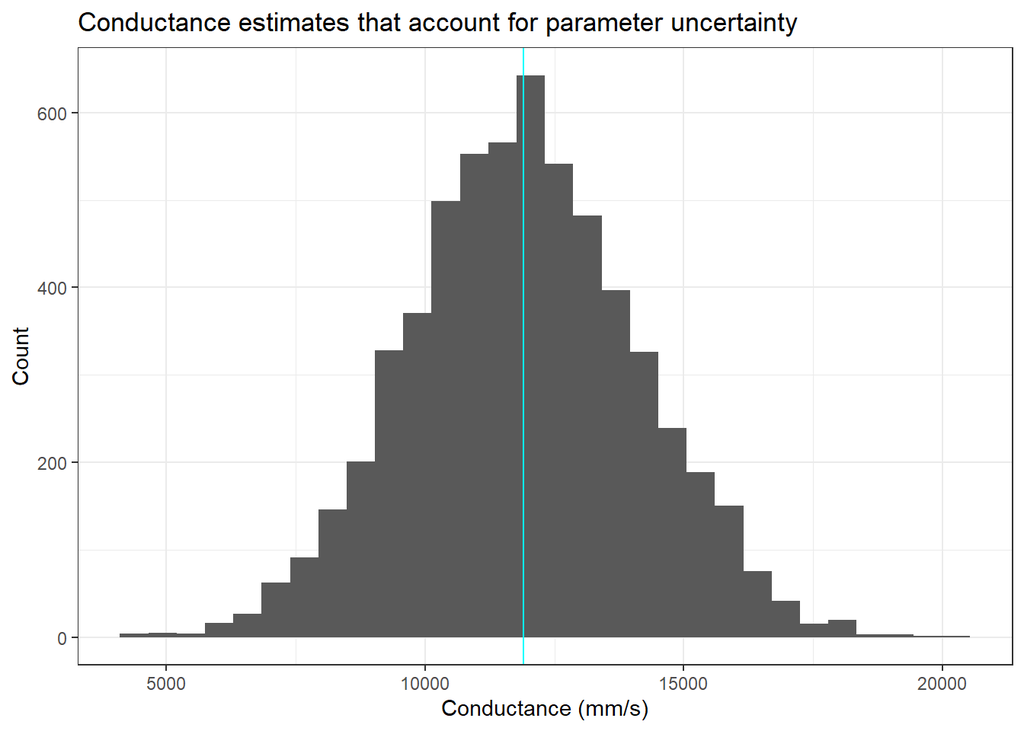

```r
# graph two most sensitive parameters
both <- cbind.data.frame(parms, gs = sens_Catm_Sobol$y)

# look at overall gs sensitvity to uncertainty
ggplot(both, aes(x = gs)) +
  geom_histogram() +
  geom_vline(xintercept = mean(both$gs), col = "cyan") +
  labs(title = "Conductance estimates that account for parameter uncertainty",
       x = "Conductance (mm/s)",
       y = "Count") +
  theme_bw()
```

**D)**

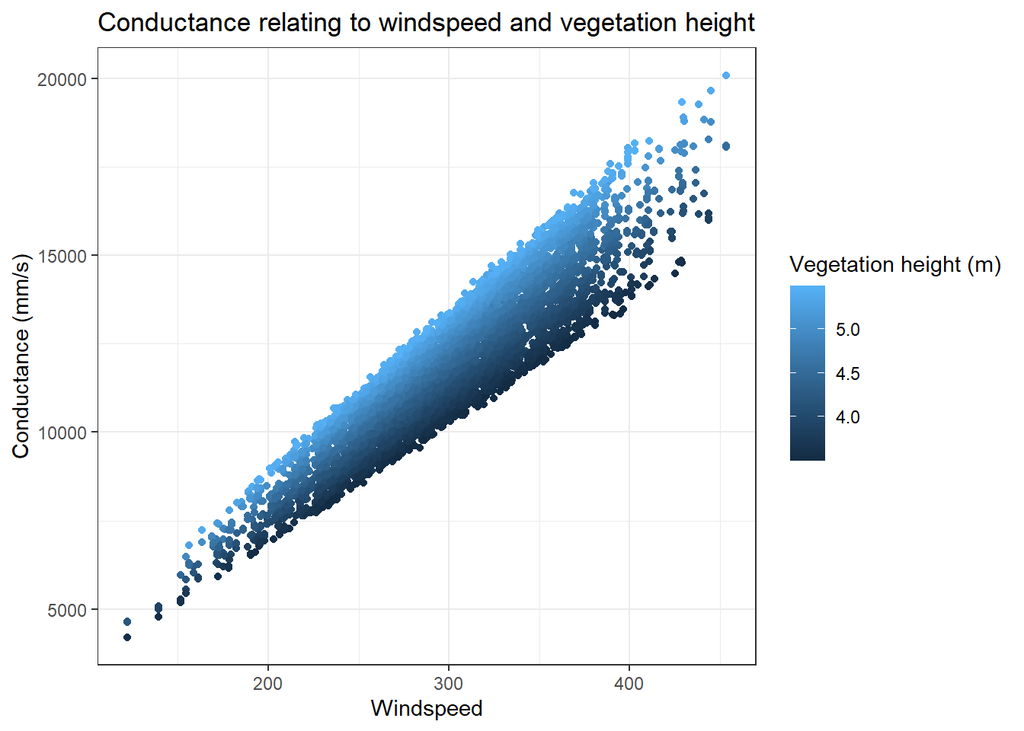

```r
# look at response of conductance to the two interesting variables
ggplot(both, aes(v, gs, col = height)) +
  geom_point() +
  labs(title = "Conductance relating to windspeed and vegetation height",
    y = "Conductance (mm/s)",
    x = "Windspeed",
    color = "Vegetation height (m)") +
  theme_bw()
```

**E)**

```r
# Estimate the Sobol indices of my output
sens_Catm_Sobol <- sensitivity::tell(sens_Catm_Sobol, res, res.names = "ga")
print(sens_Catm_Sobol)
```

```
Call:
sobolSalt(model = NULL, X1 = X1, X2 = X2, nboot = 100)

Model runs: 6000

Model variance: 4980657

First order indices:
      original          bias  std. error   min. c.i.  max. c.i.
X1 -0.02938673  0.0007205061 0.031626070 -0.09180068 0.02987706
X2 -0.03218385  0.0006194658 0.031652546 -0.09310365 0.02721427
X3  0.82730642 -0.0010193683 0.008743385  0.81185552 0.84629672
X4  0.15874475  0.0007406804 0.031000251  0.08956537 0.21636026

Total indices:
       original          bias   std. error    min. c.i.    max. c.i.
X1 1.507449e-03  1.620374e-05 9.437521e-05 1.281975e-03 1.646446e-03
X2 3.004774e-05  1.851178e-07 1.949153e-06 2.558207e-05 3.390108e-05
X3 8.566411e-01 -1.275875e-03 3.081950e-02 7.940857e-01 9.215202e-01
X4 1.672470e-01  1.406495e-03 9.653781e-03 1.454622e-01 1.816255e-01
```

**F)**